# Tarea 1 Mineria de Datos

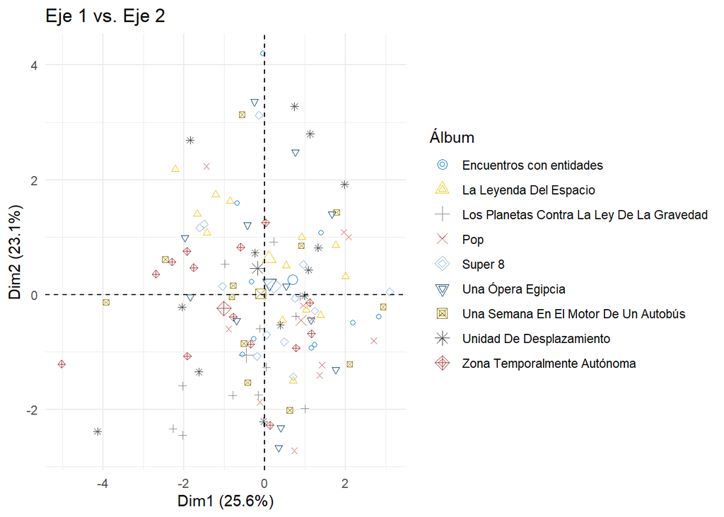

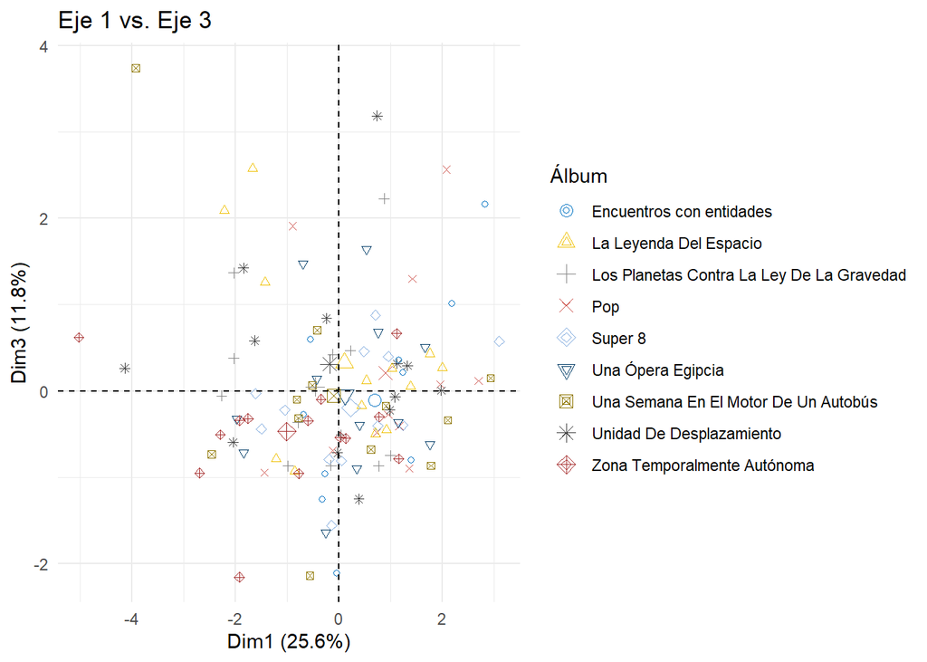

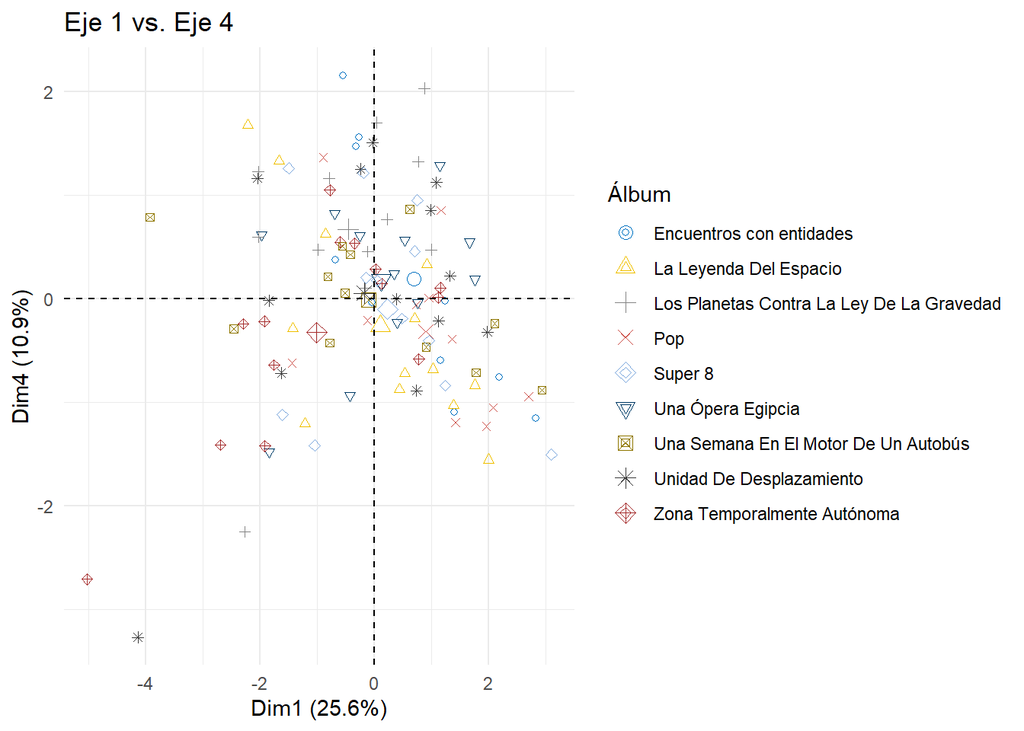

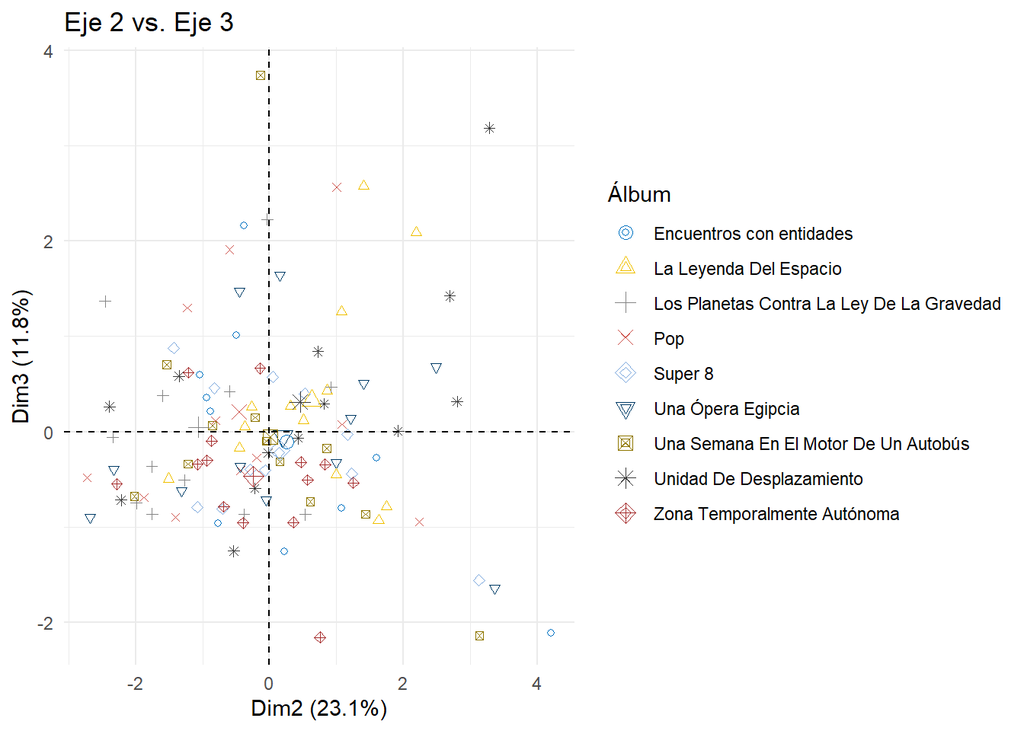

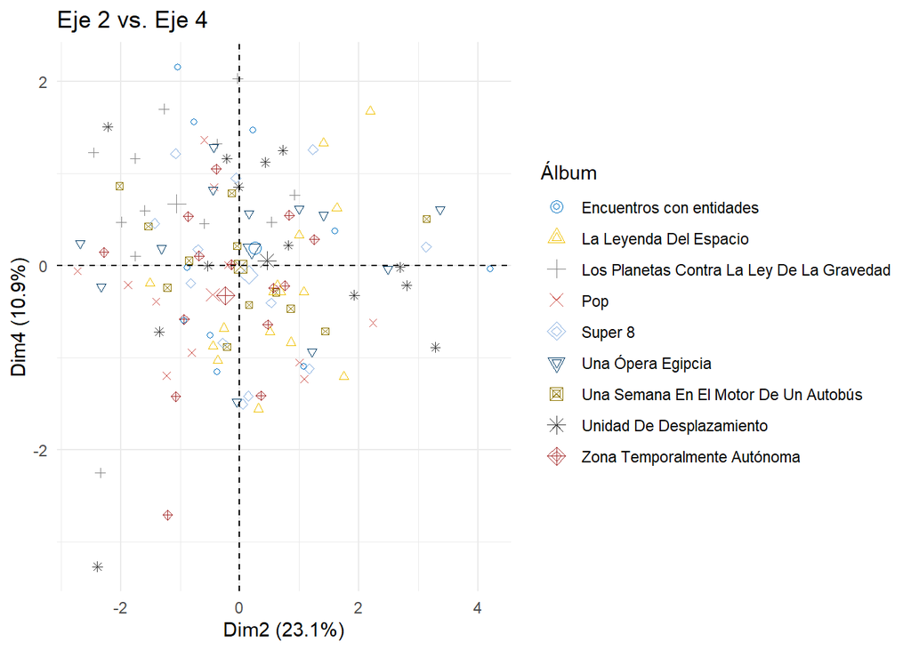

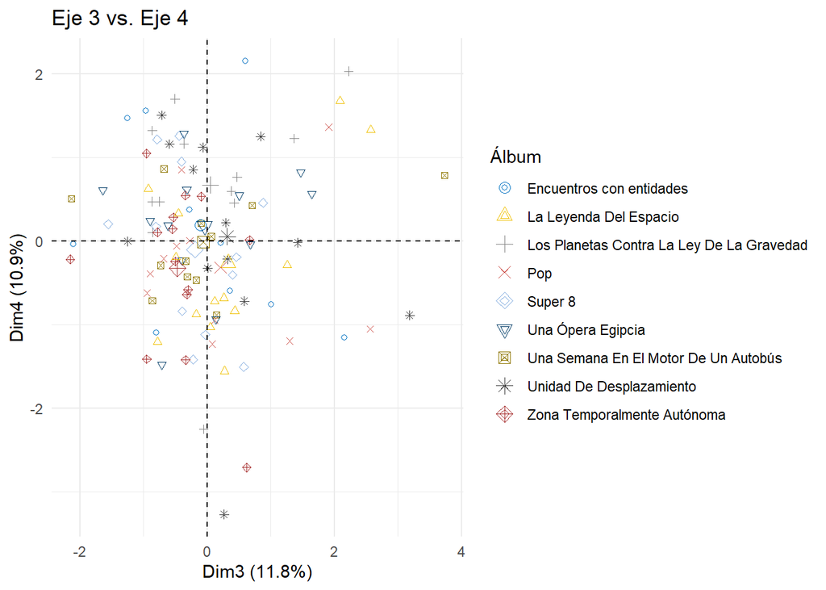

```r
library(gridExtra) # Cargar librería para manipulación de gráficos

# Inicializar lista para almacenar gráficos y contador
plots <- list()
count <- 1

# Bucle para generar gráficos de PCA para todas las combinaciones de los primeros 4 ejes
for(i in 1:3) {
  for(j in (i+1):4) {
    p <- fviz_pca_ind(res,
                      axes = c(i, j), # Especifica los ejes a visualizar
                      geom.ind = "point", # Usa puntos para representar las observaciones
                      habillage = 1, # Colorea por la primera variable cualitativa (ej. álbum)
                      palette = "jco", # Estilo de colores
                      addEllipses = FALSE, # No añadir elipses de confianza
                      legend.title = "Álbum") + # Título de leyenda
      theme_minimal() + # Tema minimalista para el gráfico
      ggtitle(paste("Eje", i, "vs. Eje", j)) # Añadir título al gráfico

    # Mostrar el gráfico
    print(p)
  }
}
```

Basándonos en la interpretación de los gráficos de individuos generados a partir del análisis PCA, donde consideramos los álbumes como variables cualitativas suplementarias, observamos una notable dispersión entre las canciones pertenecientes a los mismos álbumes. Esta inclusión de los álbumes en el análisis nos permite examinar cómo las agrupaciones de canciones por álbum se relacionan con diversas características musicales. Sin embargo, recordando los círculos de correlación analizados previamente, podemos extraer algunas conclusiones interesantes sobre la naturaleza y características de ciertos álbumes en relación con los atributos musicales evaluados:

Álbum “Zona Temporalmente Autónoma”: Su tendencia hacia la acústica se ve en los planos factoriales 1 y 2, sugiriendo una proximidad a sonidos orgánicos y posiblemente una duración extendida de las pistas, como insinúa su posición en el plano 1.3. Además, el plano 2.4 refuerza su naturaleza acústica, subrayando una producción menos electrónica y más enfocada en elementos sonoros puros.

Álbum “Pop”: Su alta valencia, evidente en el plano 1 y 2, indica un álbum lleno de canciones alegres y optimistas. Este carácter se confirma en el plano 2.3, donde también se destaca por su energía y positividad.

Álbum “Los Planetas contra la Ley de la Gravedad”: Su inclinación hacia la ‘danceability’ se nota en los planos 1 y 2, sugerente de ritmos que invitan al movimiento. Además, la presencia de elementos instrumentales se sugiere en el plano 1.4, mientras que los planos 2.3 y 2.4 lo perfilan como un álbum con una mezcla de alta ‘danceability’ y valencia, y el plano 3.4 destaca su componente instrumental.

Álbum “Unidad de Desplazamiento” y “La leyenda del espacio” muestran similitudes en liveness, especialmente en el plano 1.3, indicando una presencia palpable de energía en vivo. El plano 2.3 adicionalmente sugiere que “La leyenda del espacio” comparte esta característica, con matices de ‘speechiness’.

Álbum “Super 8” parece distinguirse por la duración de sus pistas, como lo indica su posición en el plano 2.3, insinuando que podría contener canciones más largas de lo habitual.

Álbumes “Una semana en el motor de un autobús” y “Una Opera egipcia” se caracterizan por su diversidad, sugiriendo una amplia gama de estilos y sonidos, lo que podría reflejarse en una variabilidad considerable en sus atributos musicales a través de los distintos planos factoriales.

No se añadieron elipses a las nubes de individuos debido a que estas se sobreponian y no se lograba interpretar bien debido a la dispersión que existe entre las canciones de cada album

## 2.3 3.

Explique el funcionamiento de los ejes de variables. ¿Qué separa el primer y el segundo eje?

Se podría ver desde dos enfoques, uno apartir de los planos factoriales generados en el primer punto y otro interpretando las dimensiones como tal:

Con los planos factoriales del primer punto:

### 2.3.1 Eje 1 vs Eje 2

El primer eje horizontal (Dim1) explica el 25.6% de la variabilidad en los datos. Las variables que más contribuyen en esta dirección son ‘energy’, ‘tempo’ y ‘speechiness’, indicando que este eje podría estar representando aspectos de la música relacionados con el ritmo y la presencia de voz. Las flechas apuntando hacia la derecha sugieren que altos valores en estas variables se asocian con una mayor puntuación en el primer componente principal.

### 2.3.2 Eje 1 vs Eje 3

El primer eje, como se indicó anteriormente, explica el 25.6% de la variabilidad y parece estar relacionado con características como ‘energy’, ‘tempo’, ‘speechiness’, y ‘valence’. Estas variables tienen proyecciones largas hacia la derecha, indicando que una mayor energía, un tempo más rápido, más presencia de voz y un mayor valor de valencia se asocian con puntuaciones más altas en Dim1.

El tercer eje (Dim3), que explica el 11.8% de la variabilidad, presenta un nuevo conjunto de relaciones entre las variables y la variabilidad de los datos. Por ejemplo, ‘liveness’ tiene una proyección larga hacia arriba en Dim3, lo que indica que las grabaciones con mayor presencia de audiencia en vivo o un sonido más ‘vivo’ tendrán puntuaciones más altas en este componente.

### 2.3.3 Eje 1 vs Eje 4

El primer eje horizontal (Dim1), que explica el 25.6% de la variabilidad en los datos, tiene una fuerte correlación con las variables ‘energy’, ‘tempo’ y ‘speechiness’. Esto indica que este eje podría representar aspectos dinámicos y expresivos de la música, ya que altos valores en estas variables se asocian con una mayor puntuación en Dim1, sugiriendo que las canciones más energéticas, rápidas y vocales están agrupadas en esta dirección.

Al combinar el primer y el cuarto ejes, no obtenemos una suma directa de la variabilidad porque no son ejes consecutivos. Sin embargo, aún representan dimensiones independientes de la variabilidad en los datos.

### 2.3.4 Eje 2 vs Eje 3

Juntos, el segundo y tercer eje no suman directamente su variabilidad como lo harían el primero y segundo ejes, pero combinados explican un 34.9% de la variabilidad total de los datos.

### 2.3.6 Eje 3 vs 4

El cuarto eje vertical (Dim4), que explica el 10.9% de la variabilidad, tiene una fuerte proyección de ‘instrumentalness’, indicando que esta dimensión podría estar representando la naturaleza instrumental o no vocal de la música. ‘Speechiness’ y ‘acousticness’ también se proyectan en Dim4, pero en direcciones opuestas, lo que sugiere que este eje podría estar diferenciando entre pistas habladas o con contenido de palabra hablada frente a aquellas que son más acústicas.

Juntos, el tercer y cuarto eje no suman su variabilidad de manera directa porque no son ejes consecutivos, pero combinados explican un 22.7% de la variabilidad total de los datos.

Para comprender el papel de cada eje en un Análisis de Componentes Principales (PCA), podemos revisar la resumen que muestran las coordenadas de las variables, sus contribuciones y la calidad de representación (cos²) en los ejes. Estos elementos son cruciales para discernir qué atributos musicales son los más relevantes en cada componente principal y cómo contribuyen a la variabilidad general de los datos. e.

```r
# Cargar el paquete corrplot para visualización de matrices de correlación
library(corrplot)

# Extraer información de las variables del resultado PCA
var <- get_pca_var(pca_result)

# Mostrar las coordenadas de las variables en los componentes principales
head(var$coord)
```

```
##                    Dim.1      Dim.2       Dim.3      Dim.4
## duration     -0.34267136  0.6286043 -0.39046744  0.1261598
## tempo         0.46259354  0.4348083 -0.14270295 -0.1362595
## valence       0.54877497 -0.6344625  0.08280936  0.2592775
## danceability -0.08863328 -0.8278805 -0.08899553  0.1718953
## energy        0.88771373  0.1241177 -0.11899783  0.1533629
## acousticness -0.65217977 -0.2091562  0.16272619 -0.4657803
```

```r
# Mostrar cos2 para entender la calidad de representación de las variables en el mapa de factores
head(var$cos2)
```

```
##                    Dim.1      Dim.2       Dim.3      Dim.4
## duration     0.117423662 0.39514339 0.152464822 0.01591630
## tempo        0.213992782 0.18905828 0.020364132 0.01856664
## valence      0.301153964 0.40254265 0.006857390 0.06722482
## danceability 0.007855858 0.68538608 0.007920204 0.02954798
## energy       0.788035672 0.01540519 0.014160484 0.02352019
## acousticness 0.425338455 0.04374630 0.026479813 0.21695132
```

```r
# Mostrar contribuciones de las variables a los componentes principales
head(var$contrib)
```

```
##                   Dim.1      Dim.2      Dim.3     Dim.4
## duration      5.0983279 19.0056605 14.3054650  1.628836
## tempo         9.2911884  9.0933508  1.9107252  1.900065
## valence      13.0755729 19.3615509  0.6434150  6.879625
## danceability  0.3410875 32.9657928  0.7431367  3.023869
## energy       34.2151162  0.7409611  1.3286495  2.406999
## acousticness 18.4674440  2.1041156  2.4845471 22.202272
```

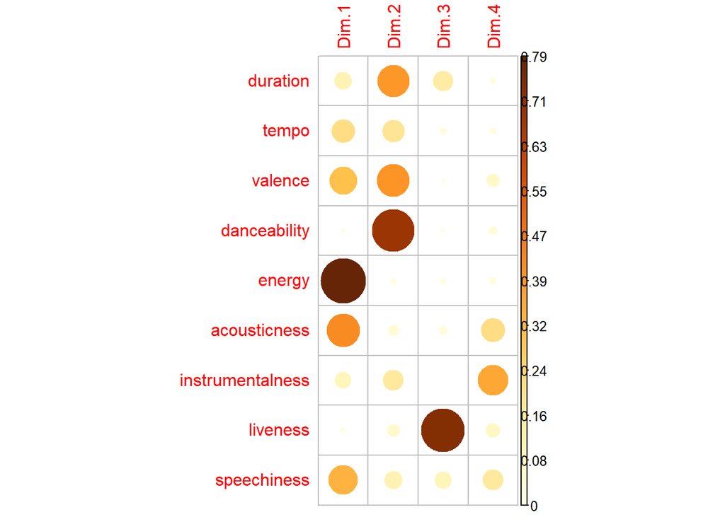

```r
# Visualizar el cos2 de las variables usando corrplot, no interpretar como correlaciones
corrplot(var$cos2, is.corr=FALSE)
```

El primer eje, o Dimensión 1, se caracteriza por la preponderancia de la energía (energy), que presenta la mayor carga positiva en este eje. Le siguen la valencia (valence) y el tempo (tempo), lo que sugiere que este eje captura primordialmente la energía de las canciones, complementada significativamente por su positividad y ritmo. Este eje distingue, por tanto, las canciones con un carácter más enérgico y estimulante de aquellas con un tono más lento y sosegado.

El segundo eje, o Dimensión 2, se define por la alta carga negativa de la danzabilidad (danceability) y la carga positiva de la duración (duration), con la valencia (valence) también mostrando una carga notable aunque negativa. Este eje parece diferenciar las canciones más propensas al baile, que suelen ser más cortas y alegres, de aquellas que son más largas y, posiblemente, menos optimistas.

El tercer y cuarto eje, aunque capturan menos variabilidad y son típicamente de menor interpretación en PCA, también aportan sus matices distintivos. La duración vuelve a destacarse en el tercer eje con una carga alta negativa, lo que podría implicar un enfoque en aspectos estructurales de las canciones no capturados por los dos primeros ejes. En cuanto al cuarto eje,

la acústica (acousticness) se manifiesta con la carga más alta en sentido negativo, lo que podría reflejar una distinción entre las canciones con elementos acústicos frente a aquellas con una producción más electrónica o procesada.

Además, La separación entre el primer y el segundo eje radica en que cada uno captura diferentes aspectos de la variabilidad en los datos. El primer eje captura la mayor variabilidad posible, mientras que el segundo eje captura la mayor variabilidad posible que es ortogonal (independiente) al primer eje.

## 2.4 4.

¿La proyección es suficientemente buena para poder interpretar los datos para todas las variables? Justifique su respuesta

Para determinar si la proyección de un Análisis de Componentes Principales (PCA) es suficiente para interpretar los datos, se debe evaluar la calidad de la representación de cada variable en los componentes principales, lo cual se refleja en los valores de cos². El cos² indica la proporción de la varianza de la variable que es capturada por cada dimensión del PCA. En general, un valor de cos² cercano a 1 significa que la variable está muy bien representada en esa dimensión, mientras que un valor cercano a 0 indica una representación pobre.

```r
# Extraer información de las variables del resultado del PCA
var <- get_pca_var(pca_result)

# Inspeccionar la estructura de 'var'
var
```

```
## Principal Component Analysis Results for variables
##  ===================================================
##   Name       Description
## 1 "$coord"   "Coordinates for the variables"
## 2 "$cor"     "Correlations between variables and dimensions"
## 3 "$cos2"    "Cos2 for the variables"
## 4 "$contrib" "contributions of the variables"
```

```r
# Mostrar los primeros valores de cos2 para evaluar la calidad de representación de cada variable
head(var$cos2)
```

```
##                    Dim.1      Dim.2       Dim.3      Dim.4
## duration     0.117423662 0.39514339 0.152464822 0.01591630
## tempo        0.213992782 0.18905828 0.020364132 0.01856664
## valence      0.301153964 0.40254265 0.006857390 0.06722482
## danceability 0.007855858 0.68538608 0.007920204 0.02954798
## energy       0.788035672 0.01540519 0.014160484 0.02352019
## acousticness 0.425338455 0.04374630 0.026479813 0.21695132
```

Energía (energy): Tiene un cos² de 0.788 en la Dimensión 1, lo que indica que esta variable está muy bien representada en el primer componente. Es decir, la Dimensión 1 es un fuerte indicador del nivel de energía en las canciones.

Danzabilidad (danceability): Con un cos² de 0.685 en la Dimensión 2, la danzabilidad está bien representada en el segundo componente, lo que significa que la Dimensión 2 es un buen reflejo de la aptitud de las canciones para el baile.

Acústica (acousticness): Tiene un cos² relativamente alto de 0.425 en la Dimensión 1, y también una representación significativa en la Dimensión 4 con un cos² de 0.217. Esto sugiere que la Dimensión 1 captura una parte importante de la acústica, pero para una interpretación completa, se debería considerar también la Dimensión 4.

Para las demás variables como duración (duration), tempo, y valencia (valence), aunque tienen representaciones significativas en varias dimensiones, no hay una dimensión donde su cos² sea extremadamente alto, lo que sugiere que ninguna dimensión por sí sola las captura completamente.

# 3 Punto

La reducción de dimensionalidad no se centra únicamente en las aproximaciones que proyectan los datos en una dimensión diferente como en el caso de PCA, MCA o KPCA. También se incluye la selección o eliminación de las variables menos representativas por lo que hay herramientas como la selección recursiva hacia adelante o hacia atrás. Sin embargo, hay otras alternativas que puede usar en este sentido como los métodos Wrapper como el caso de la eliminación recursiva de rasgos (RFE) o filtros como la importancia de variables. Con base en lo anterior:

1. Investigue cuáles son los métodos más usados para hacer selección de rasgos y describa su funcionamiento a través de R con un ejemplo con la base de datos de expertos de Vino disponible en Bloque Neón con nombre“data_PCA_ExpertWine.csv”

#### 3.0.0.1 **RESPUESTA**:

Las librerias que se necesitan para el desarrollo de este punto son las siguientes:

```r
library(readr)
library(MASS)
library(dplyr)
library(randomForest)
library(caret)
library(e1071)
```

Como primer paso se lee la base de datos, de la siguiente forma:

```r
data_PCA_ExpertWine <- read_delim("data_PCA_ExpertWine.csv",delim = ";", escape_double = FALSE, trim_ws = TRUE)
```

```
## ──────────────────────────────────────────────────────── Delimiter: ";" chr
## (2): ...1, Label dbl (29): O.fruity, O.passion, O.citrus,
## O.Intensity.before.shaking, O.Inten...
```

```r
data_PCA_ExpertWine$Label <- as.factor(data_PCA_ExpertWine$Label)
# Establecer la columna 'id' como el índice
rownames(data_PCA_ExpertWine) <- data_PCA_ExpertWine$...1

# Eliminar la columna 'id' del dataframe
data_PCA_ExpertWine <- data_PCA_ExpertWine[, -1]
data_PCA_ExpertWine$Label
```

```
##  [1] Sauvignon Sauvignon Sauvignon Sauvignon Sauvignon Vouvray   Vouvray
##  [8] Vouvray   Vouvray   Vouvray
## Levels: Sauvignon Vouvray
```

### 3.0.1 1. Filtrado de importancia de variables:

Este método evalúa cada característica individualmente mediante el análisis de medidas estadísticas para determinar su relevancia en la predicción de la variable objetivo. Las características se clasifican según su capacidad predictiva, que puede ser evaluada mediante su correlación con la variable de salida o su importancia estadística. Usualmente, se aplica antes del modelado de los datos para seleccionar las características más relevantes.

Se pueden emplear diversas formas de evaluar la correlación entre las variables:

1. Para variables explicativas y la variable a predecir continuas, se puede utilizar la correlación de Pearson.
2. Cuando las variables explicativas son categóricas y la variable a predecir es continua, se puede recurrir al ANOVA.
3. Si las variables explicativas son continuas y la variable a predecir es categórica, se puede emplear el Análisis Lineal Discriminante.
4. Para variables explicativas y la variable a predecir categóricas, se pueden aplicar pruebas de Chi-cuadrado.

Para el ejemplo en R, se utilizará el Análisis Lineal Discriminante (LDA), dado que la variable objetivo es categórica y será explicada por variables continuas.

```r
# Ajustar el modelo LDA
lda_model <- lda(Label ~ ., data = data_PCA_ExpertWine)
# Obtener las características más importantes
important_features <- lda_model$scaling

# Obtener los coeficientes de discriminación
discrimination_coef <- as.data.frame(abs(lda_model$scaling))

# Ordenar los coeficientes de discriminación
datos_organizados <- arrange(discrimination_coef, desc(LD1))

# Seleccionar las mejores características
best_features <- datos_organizados%>% filter(LD1 >= 0.2)

# Mostrar las mejores características seleccionadas
print(best_features)
```

```
##                       LD1
## Freshness       1.2604302
## Odor.preference 0.4004810
## O.passion       0.3753832
## O.mushroom      0.3670419
```

### 3.0.2 2. Wrapper Methods (Métodos de envoltura):

Estos métodos evalúan diferentes subconjuntos de características utilizando un modelo de aprendizaje automático específico, empleando técnicas de búsqueda exhaustiva (por ejemplo, forward selection, backward elimination) para encontrar el conjunto óptimo de características que maximiza el rendimiento del modelo.

La idea principal del método wrapper es seleccionar el mejor conjunto de variables al evaluar el rendimiento de un modelo mediante diferentes subconjuntos de variables. Este enfoque es especialmente relevante en el contexto de los modelos de machine learning, donde el objetivo es que el modelo actúe como una caja negra con el mejor subconjunto de variables. La selección de variables puede realizarse de manera iterativa o considerando combinaciones de todas las variables disponibles. Dentro de los métodos de Wrapper, se destacan tres enfoques específicos: la Búsqueda Exhaustiva del Mejor Subconjunto (**Exhaustive Feature Selection**), la Eliminación Secuencial (**Sequential Backward Selection/Elimination**) y la Selección Secuencial (**Sequential Forward Selection**).

A manera de muestra en el código de abajo se maneja la selección secuencial del subconjunto de variables.

```r
# Definir el problema de clasificación
problem <- data_PCA_ExpertWine[, -1]
target <- data_PCA_ExpertWine$Label

# Crear un objeto trainControl para especificar el método de validación cruzada
train_control <- trainControl(method = "cv", number = 5)

# Definir el modelo SVM
svm_model <- train(problem, target, method = "svmLinear", trControl = train_control)

# Realizar Sequential Forward Selection con el modelo SVM
ctrl <- rfeControl(functions = rfFuncs, method = "cv", number=5)
wrapper_model <- rfe(problem, target, sizes = c(1:27), rfeControl = ctrl)
print(wrapper_model$results)
```

```
##    Variables Accuracy Kappa AccuracySD   KappaSD
## 1          1      0.9   0.8  0.2236068 0.4472136
## 2          2      0.8   0.6  0.2738613 0.5477226
## 3          3      0.9   0.8  0.2236068 0.4472136
## 4          4      0.9   0.8  0.2236068 0.4472136
## 5          5      0.9   0.8  0.2236068 0.4472136
## 6          6      1.0   1.0  0.0000000 0.0000000
## 7          7      0.8   0.6  0.2738613 0.5477226
## 8          8      0.8   0.6  0.2738613 0.5477226
## 9          9      0.8   0.6  0.2738613 0.5477226
## 10        10      0.8   0.6  0.2738613 0.5477226
## 11        11      0.8   0.6  0.2738613 0.5477226
## 12        12      0.8   0.6  0.2738613 0.5477226
## 13        13      0.9   0.8  0.2236068 0.4472136
## 14        14      0.9   0.8  0.2236068 0.4472136
## 15        15      0.9   0.8  0.2236068 0.4472136
## 16        16      0.8   0.6  0.2738613 0.5477226
## 17        17      0.8   0.6  0.2738613 0.5477226
## 18        18      0.8   0.6  0.2738613 0.5477226
## 19        19      0.8   0.6  0.2738613 0.5477226
## 20        20      0.8   0.6  0.2738613 0.5477226
## 21        21      0.8   0.6  0.2738613 0.5477226
## 22        22      0.8   0.6  0.2738613 0.5477226
## 23        23      0.8   0.6  0.2738613 0.5477226
## 24        24      0.8   0.6  0.2738613 0.5477226
## 25        25      0.8   0.6  0.2738613 0.5477226
## 26        26      0.8   0.6  0.2738613 0.5477226
## 27        27      0.8   0.6  0.2738613 0.5477226
## 28        29      0.8   0.6  0.2738613 0.5477226
```

```r
# Mostrar las características seleccionadas
print(wrapper_model$optVariables)
```

```
## [1] "Freshness"  "O.passion"  "O.mushroom" "Oxidation"  "O.flower"
## [6] "O.wooded"
```

### 3.0.3 3. Embedded Methods (Métodos incrustados):

Los métodos incrustados en la selección de características son una clase de enfoques donde la selección de características se integra directamente en el proceso de entrenamiento del modelo. En lugar de realizar la selección de características como un paso independiente, los algoritmos de aprendizaje automático utilizan técnicas internas para identificar automáticamente las características más relevantes durante el proceso de entrenamiento del modelo. Esto permite que el modelo seleccione las variables más importantes según su contribución al rendimiento del modelo.

En R, varios algoritmos de aprendizaje automático, como los modelos de regularización, implementan métodos de selección de características como parte de su proceso de entrenamiento. Por ejemplo, los modelos Random Forest incorporan una técnica de selección de características que evalúa la importancia de cada característica durante el proceso de construcción del árbol. De esta manera, el modelo mismo selecciona las variables más relevantes para mejorar su rendimiento predictivo.

El ejemplo que se va a utilizar del método incrustado va a trabajar un modelo de Random Forest en R para la selección de características:

```r
# Dividir los datos en conjuntos de entrenamiento y prueba
training_index <- createDataPartition(data_PCA_ExpertWine$Label, p = 0.7, list = FALSE)
training_data <- data_PCA_ExpertWine[training_index, ]
test_data <- data_PCA_ExpertWine[-training_index, ]

# Crear un modelo Random Forest
rf_model <- randomForest(Label ~ ., data = data_PCA_ExpertWine)

# Mostrar la importancia de las características según el modelo Random Forest
print(importance(rf_model))
```

```
##                            MeanDecreaseGini
## O.fruity                         0.06981587
## O.passion                        0.47286190
## O.citrus                         0.17516667
## O.Intensity.before.shaking       0.02960000
## O.Intensity.after.shaking        0.01293333
## Expression                       0.05860000
## O.candied.fruit                  0.24423333
## O.vanilla                        0.14970000
## O.wooded                         0.37495556
## O.mushroom                       0.36470000
## O.plante                         0.14093333
## O.flower                         0.37363333
## O.alcohol                        0.12154286
## Typicity                         0.24320000
## Grade                            0.24596667
## Surface.feeling                  0.13940000
## Freshness                        0.44800000
## Oxidation                        0.26282857
## Smoothness                       0.05366667
## Attack.intensity                 0.00000000
## Sweetness                        0.03323333
## Acidity                          0.10212857
## Bitterness                       0.00540000
## Astringency                      0.04886667
## Aroma.intensity                  0.02937143
## Aroma.persistency                0.02323333
## Visual.intensity                 0.17146667
## Odor.preference                  0.05136190
## Overall.preference               0.03840000
```

```r
# Seleccionar las características más importantes
important_features <- rownames(importance(rf_model))[order(importance(rf_model), decreasing = TRUE)]

# Mostrar las características más importantes
print(important_features)
```

```
##  [1] "O.passion"                  "Freshness"
##  [3] "O.wooded"                   "O.flower"
##  [5] "O.mushroom"                 "Oxidation"
##  [7] "Grade"                      "O.candied.fruit"
##  [9] "Typicity"                   "O.citrus"
## [11] "Visual.intensity"           "O.vanilla"
## [13] "O.plante"                   "Surface.feeling"
## [15] "O.alcohol"                  "Acidity"
## [17] "O.fruity"                   "Expression"
## [19] "Smoothness"                 "Odor.preference"
## [21] "Astringency"                "Overall.preference"
## [23] "Sweetness"                  "O.Intensity.before.shaking"
## [25] "Aroma.intensity"            "Aroma.persistency"
## [27] "O.Intensity.after.shaking"  "Bitterness"
## [29] "Attack.intensity"
```

2. Explique cuáles son sus principales características y cuáles ventajas o desventajas trae su implementación. ¿Cuál contemplaría en su análisis y por qué?

#### 3.0.3.1 **RESPUESTA**:

### 3.0.4 1. Filtrado de importancia de variables:

El método de filtrado de importancia de variables se lleva a cabo antes del modelado, lo que permite una selección de características que puede ser aplicada de manera transversal a varios modelos. La evaluación se basa en medidas como la correlación o la importancia estadística, simplificando así la interpretación y el proceso de selección. Las ventajas de este enfoque son las siguientes:

1. Es altamente eficiente desde el punto de vista computacional, ya que se realiza de manera descriptiva la selección de variables.
2. Es más simple que otros métodos de selección de variables, ya que no requiere la evaluación de múltiples subconjuntos de variables mediante un modelo complejo.
3. El resultado de la selección de variables no cambia independientemente del modelo utilizado, ya que la selección se realiza antes del entrenamiento del modelo.
4. La interpretación de por qué se seleccionaron ciertas variables es sencilla y fácil de explicar a personas sin conocimientos técnicos.

Sin embargo, este método también presenta algunas desventajas:

1. No tiene en cuenta las interacciones entre variables, ya que cada variable se evalúa de manera individual.
2. No considera el funcionamiento interno del modelo seleccionado, lo que puede llevar a que algunas variables no sean representativas dentro del modelo final.

### 3.0.5 2. Wrapper Methods (Métodos de envoltura):

El método Wrapper de selección de variables implica la generación de subconjuntos de características, lo que puede lograrse de varias maneras, como mediante métodos de eliminación hacia adelante o hacia atrás, o considerando combinaciones diversas de todas las variables disponibles. Posteriormente, se evalúa cada uno de estos subconjuntos con el modelo definido para el caso particular, midiendo su rendimiento, generalmente a través de técnicas como validación cruzada, error cuadrático medio (MSE) o precisión del modelo. Se puede establecer un criterio de parada para evitar la evaluación de un número excesivo de modelos. Las ventajas de este enfoque son las siguientes:

1. El método Wrapper tiende a ofrecer una precisión muy elevada, ya que permite seleccionar y ajustar el modelo según las necesidades específicas de cada caso.
2. Se consideran las posibles interacciones entre las variables, ya que al evaluar una amplia variedad de subconjuntos, se tienen en cuenta relaciones que pueden no ser evidentes inicialmente, pero que pueden resultar significativas durante la evaluación del modelo.

Sin embargo, este método presenta algunas desventajas:

1. Es propenso a requerir mucho tiempo y poder computacional, especialmente cuando se evalúan numerosos modelos, lo que puede volverse prohibitivo en términos de recursos, especialmente para modelos de alta complejidad o para la busqueda exhaustiva de variables.
2. Existe el riesgo de sobreajustar las variables al modelo con el que se seleccionaron, lo que puede conducir a una pérdida de generalización y a un rendimiento subóptimo en datos no observados

### 3.0.6 3. Embedded Methods (Métodos incrustados):

El método embedded de selección de características lleva a cabo la selección de variables directamente durante el proceso de entrenamiento del modelo de aprendizaje automático, permitiendo que el propio modelo identifique la importancia y representatividad de las características. En lugar de tratar la selección de características como un paso independiente, este enfoque aprovecha las técnicas internas de los algoritmos de aprendizaje automático para identificar automáticamente las características más relevantes. Sus ventajas son las siguientes:

1. Elimina la necesidad de un preprocesamiento separado de las variables antes del entrenamiento del modelo. Al integrar la selección de características en el proceso de entrenamiento, se evitan los costos computacionales adicionales asociados con los pasos de modelado por separado.
2. Reduce el riesgo de sobreajuste, ya que el modelo selecciona el mejor subconjunto de variables de acuerdo con los parámetros predefinidos, lo que permite un equilibrio más efectivo entre la complejidad del modelo y su capacidad de generalización.

Sin embargo, este método presenta algunas desventajas:

1. No todos los modelos de aprendizaje automático incorporan técnicas de selección de características integradas, lo que limita su aplicabilidad. Es importante conocer qué modelos admiten este enfoque.
2. La efectividad de la selección de características depende en gran medida del rendimiento y la capacidad de generalización del modelo utilizado. No todos los modelos ofrecen los mismos resultados, y la selección de características puede variar según las características específicas del modelo.

Para conjuntos de datos con una cantidad limitada de muestras, como en el caso de “data_PCA_ExpertWine.csv”, donde la información sobre los vinos es escasa, el enfoque más adecuado para evaluar la importancia de las variables es el de Filtrado de la importancia de las variables. Dado que no se dispone de poca información para una ejecución exitosa de los modelos, es más práctico interpretar la relación entre las variables explicativas y la variable “Label” mediante un análisis discriminante lineal.